# Project 1: Predict Bike Sharing Demand with AutoGluon

#### May 10, 2024

## Step 1: Create an account with Kaggle

## Step 2: Download the Kaggle dataset using the kaggle python library

### Install packages

```python
!pip install -qU pip
!pip install -qU setuptools wheel
!pip install -qU "mxnet<2.0.0"
!pip install bokeh==2.0.1
!pip install autogluon --no-cache-dir
# Without --no-cache-dir, smaller aws instances may have trouble installing
!pip install -qU kaggle
```

[output not shown]

[output cut: 188 more lines]

[output not shown]

```
WARNING: Running pip as the 'root' user can result in broken permissions and conflicting behaviour with the system package manager. It is recommended to use a virtual environment instead: https://pip.pypa.io/warnings/venv
```

### Setup Kaggle API Key

```python
import json
import os
```

```python
# create the .kaggle directory and an empty kaggle.json file
!mkdir -p /root/.kaggle
!touch /root/.kaggle/kaggle.json
!chmod 600 /root/.kaggle/kaggle.json
```

```python
# Upload json token to the working directory
with open('./kaggle.json', 'r') as f:
    kaggle_json = f.read()
    kaggle = json.loads(kaggle_json)

kaggle_username = kaggle['username']
kaggle_key = kaggle['key']

# Save API token the kaggle.json file
with open("/root/.kaggle/kaggle.json", "w") as f:
    f.write(json.dumps({"username": kaggle_username, "key": kaggle_key}))
```

### Download and explore dataset

### Go to the [bike sharing demand competition](https://www.kaggle.com/c/bike-sharing-demand) and agree to the terms

```python
# Download the dataset, it will be in a .zip file so you'll need to unzip it as well.
!kaggle competitions download -c bike-sharing-demand
# If you already downloaded it you can use the -o command to overwrite the file
!unzip -o bike-sharing-demand.zip
```

```
Downloading bike-sharing-demand.zip to /content
  0% 0.00/189k [00:00<?, ?B/s]
100% 189k/189k [00:00<00:00, 44.3MB/s]
Archive:  bike-sharing-demand.zip
  inflating: sampleSubmission.csv
  inflating: test.csv
  inflating: train.csv
```

```python
import pandas as pd
import matplotlib.pyplot as plt
import matplotlib.dates as mdates
import seaborn as sns
import numpy as np

from sklearn import datasets
from sklearn.metrics import r2_score, accuracy_score
from sklearn.model_selection import train_test_split
from autogluon.tabular import TabularDataset, TabularPredictor
```

```python
# Create the train dataset in pandas by reading the csv
# Set the parsing of the datetime column so you can use some of the `dt` features in pandas later
train = pd.read_csv('train.csv')
train.head()
```

|  | datetime | season | holiday | workingday | weather | temp | atemp | humidity | windspeed | casual | registered | count |
| --- | --- | --- | --- | --- | --- | --- | --- | --- | --- | --- | --- | --- |
| 0 | 2011-01-01 00:00:00 | 1 | 0 | 0 | 1 | 9.84 | 14.395 | 81 | 0.0 | 3 | 13 | 16 |
| 1 | 2011-01-01 01:00:00 | 1 | 0 | 0 | 1 | 9.02 | 13.635 | 80 | 0.0 | 8 | 32 | 40 |
| 2 | 2011-01-01 02:00:00 | 1 | 0 | 0 | 1 | 9.02 | 13.635 | 80 | 0.0 | 5 | 27 | 32 |
| 3 | 2011-01-01 03:00:00 | 1 | 0 | 0 | 1 | 9.84 | 14.395 | 75 | 0.0 | 3 | 10 | 13 |
| 4 | 2011-01-01 04:00:00 | 1 | 0 | 0 | 1 | 9.84 | 14.395 | 75 | 0.0 | 0 | 1 | 1 |

```python
# Simple output of the train dataset to view some of the min/max/varition of the dataset features.
train.describe()
```

|  | season | holiday | workingday | weather | temp | atemp | humidity | windspeed | casual | registered | count |
| --- | --- | --- | --- | --- | --- | --- | --- | --- | --- | --- | --- |
| count | 10886.000000 | 10886.000000 | 10886.000000 | 10886.000000 | 10886.00000 | 10886.000000 | 10886.000000 | 10886.000000 | 10886.000000 | 10886.000000 | 10886.000000 |
| mean | 2.506614 | 0.028569 | 0.680875 | 1.418427 | 20.23086 | 23.655084 | 61.886460 | 12.799395 | 36.021955 | 155.552177 | 191.574132 |
| std | 1.116174 | 0.166599 | 0.466159 | 0.633839 | 7.79159 | 8.474601 | 19.245033 | 8.164537 | 49.960477 | 151.039033 | 181.144454 |
| min | 1.000000 | 0.000000 | 0.000000 | 1.000000 | 0.82000 | 0.760000 | 0.000000 | 0.000000 | 0.000000 | 0.000000 | 1.000000 |
| 25% | 2.000000 | 0.000000 | 0.000000 | 1.000000 | 13.94000 | 16.665000 | 47.000000 | 7.001500 | 4.000000 | 36.000000 | 42.000000 |
| 50% | 3.000000 | 0.000000 | 1.000000 | 1.000000 | 20.50000 | 24.240000 | 62.000000 | 12.998000 | 17.000000 | 118.000000 | 145.000000 |
| 75% | 4.000000 | 0.000000 | 1.000000 | 2.000000 | 26.24000 | 31.060000 | 77.000000 | 16.997900 | 49.000000 | 222.000000 | 284.000000 |
| max | 4.000000 | 1.000000 | 1.000000 | 4.000000 | 41.00000 | 45.455000 | 100.000000 | 56.996900 | 367.000000 | 886.000000 | 977.000000 |

```python
# Create the test pandas dataframe in pandas by reading the csv, remember to parse the datetime!
test = pd.read_csv('test.csv')
test.head()
```

|  | datetime | season | holiday | workingday | weather | temp | atemp | humidity | windspeed |
| --- | --- | --- | --- | --- | --- | --- | --- | --- | --- |
| 0 | 2011-01-20 00:00:00 | 1 | 0 | 1 | 1 | 10.66 | 11.365 | 56 | 26.0027 |
| 1 | 2011-01-20 01:00:00 | 1 | 0 | 1 | 1 | 10.66 | 13.635 | 56 | 0.0000 |
| 2 | 2011-01-20 02:00:00 | 1 | 0 | 1 | 1 | 10.66 | 13.635 | 56 | 0.0000 |
| 3 | 2011-01-20 03:00:00 | 1 | 0 | 1 | 1 | 10.66 | 12.880 | 56 | 11.0014 |
| 4 | 2011-01-20 04:00:00 | 1 | 0 | 1 | 1 | 10.66 | 12.880 | 56 | 11.0014 |

```python
# Same thing as train and test dataset
submission = pd.read_csv('sampleSubmission.csv')
submission.head()
```

|  | datetime | count |
| --- | --- | --- |
| 0 | 2011-01-20 00:00:00 | 0 |
| 1 | 2011-01-20 01:00:00 | 0 |
| 2 | 2011-01-20 02:00:00 | 0 |
| 3 | 2011-01-20 03:00:00 | 0 |
| 4 | 2011-01-20 04:00:00 | 0 |

## Step 3: Train a model using AutoGluon’s Tabular Prediction

Requirements:

- We are predicting `count`, so it is the label we are setting.
- Ignore `casual` and `registered` columns as they are also not present in the test dataset.
- Use the `root_mean_squared_error` as the metric to use for evaluation.
- Set a time limit of 10 minutes (600 seconds).
- Use the preset `best_quality` to focus on creating the best model.

```python
train.columns
```

```
Index(['datetime', 'season', 'holiday', 'workingday', 'weather', 'temp',
       'atemp', 'humidity', 'windspeed', 'casual', 'registered', 'count'],
      dtype='object')
```

```python
label = 'count'

predictor = TabularPredictor(
    label=label,
    eval_metric='root_mean_squared_error'
).fit(
    train_data = train.drop(columns=['casual', 'registered']),
    presets='best_quality',
    time_limit=600
)
```

```
No path specified. Models will be saved in: "AutogluonModels/ag-20240510_173256"
Presets specified: ['best_quality']
Setting dynamic_stacking from 'auto' to True. Reason: Enable dynamic_stacking when use_bag_holdout is disabled. (use_bag_holdout=False)
Stack configuration (auto_stack=True): num_stack_levels=1, num_bag_folds=8, num_bag_sets=1
Dynamic stacking is enabled (dynamic_stacking=True). AutoGluon will try to determine whether the input data is affected by stacked overfitting and enable or disable stacking as a consequence.
Detecting stacked overfitting by sub-fitting AutoGluon on the input data. That is, copies of AutoGluon will be sub-fit on subset(s) of the data. Then, the holdout validation data is used to detect stacked overfitting.
Sub-fit(s) time limit is: 600 seconds.
Starting holdout-based sub-fit for dynamic stacking. Context path is: AutogluonModels/ag-20240510_173256/ds_sub_fit/sub_fit_ho.
Running the sub-fit in a ray process to avoid memory leakage.
Spend 185 seconds for the sub-fit(s) during dynamic stacking.
Time left for full fit of AutoGluon: 415 seconds.
Starting full fit now with num_stack_levels 1.
Beginning AutoGluon training ... Time limit = 415s
AutoGluon will save models to "AutogluonModels/ag-20240510_173256"
=================== System Info ===================
AutoGluon Version:  1.1.0
Python Version:     3.10.12
Operating System:   Linux
Platform Machine:   x86_64
Platform Version:   #1 SMP PREEMPT_DYNAMIC Sat Nov 18 15:31:17 UTC 2023
CPU Count:          2
Memory Avail:       10.26 GB / 12.67 GB (81.0%)
Disk Space Avail:   75.04 GB / 107.72 GB (69.7%)
===================================================
Train Data Rows:    10886
Train Data Columns: 9
Label Column:       count
Problem Type:       regression
Preprocessing data ...
Using Feature Generators to preprocess the data ...
Fitting AutoMLPipelineFeatureGenerator...
	Available Memory:                    10510.02 MB
	Train Data (Original)  Memory Usage: 1.45 MB (0.0% of available memory)
	Inferring data type of each feature based on column values. Set feature_metadata_in to manually specify special dtypes of the features.
	Stage 1 Generators:
		Fitting AsTypeFeatureGenerator...
			Note: Converting 2 features to boolean dtype as they only contain 2 unique values.
	Stage 2 Generators:
		Fitting FillNaFeatureGenerator...
	Stage 3 Generators:
```

[output cut: 75 more lines]

```
	Fitting 8 child models (S1F1 - S1F8) | Fitting with ParallelLocalFoldFittingStrategy (2 workers, per: cpus=1, gpus=0, memory=0.11%)
	-55.1178	 = Validation score   (-root_mean_squared_error)
	35.23s	 = Training   runtime
	0.31s	 = Validation runtime
Fitting model: RandomForestMSE_BAG_L2 ... Training model for up to 15.8s of the 14.97s of remaining time.
	-53.4085	 = Validation score   (-root_mean_squared_error)
	46.77s	 = Training   runtime
	0.7s	 = Validation runtime
Fitting model: WeightedEnsemble_L3 ... Training model for up to 360.0s of the -34.37s of remaining time.
	Ensemble Weights: {'RandomForestMSE_BAG_L2': 0.727, 'LightGBM_BAG_L2': 0.227, 'LightGBMXT_BAG_L2': 0.045}
	-53.1295	 = Validation score   (-root_mean_squared_error)
	0.06s	 = Training   runtime
	0.0s	 = Validation runtime
AutoGluon training complete, total runtime = 451.01s ... Best model: "WeightedEnsemble_L3"
TabularPredictor saved. To load, use: predictor = TabularPredictor.load("AutogluonModels/ag-20240510_173256")
```

### Review AutoGluon's training run with ranking of models that did the best.

```python
predictor.fit_summary()
```

```
*** Summary of fit() ***
Estimated performance of each model:
                     model   score_val              eval_metric  pred_time_val    fit_time  pred_time_val_marginal  fit_time_marginal  stack_level  can_infer  fit_order
0      WeightedEnsemble_L3  -53.129508  root_mean_squared_error      23.509402  407.770691                0.001145           0.064162            3       True         11
1   RandomForestMSE_BAG_L2  -53.408530  root_mean_squared_error      17.891692  298.822307                0.704573          46.771509            2       True         10
2          LightGBM_BAG_L2  -55.117845  root_mean_squared_error      17.500974  287.279576                0.313855          35.228778            2       True          9
3        LightGBMXT_BAG_L2  -60.584515  root_mean_squared_error      22.489828  325.706242                5.302710          73.655444            2       True          8
4    KNeighborsDist_BAG_L1  -84.125061  root_mean_squared_error       0.056424    0.036695                0.056424           0.036695            1       True          2
5      WeightedEnsemble_L2  -84.125061  root_mean_squared_error       0.058124    0.100007                0.001700           0.063312            2       True          7
6    KNeighborsUnif_BAG_L1 -101.546199  root_mean_squared_error       0.056834    0.038084                0.056834           0.038084            1       True          1
7   RandomForestMSE_BAG_L1 -116.548359  root_mean_squared_error       0.706532   21.464537                0.706532          21.464537            1       True          5
8          LightGBM_BAG_L1 -131.054162  root_mean_squared_error       2.482318   42.297859                2.482318          42.297859            1       True          4
9          CatBoost_BAG_L1 -131.314360  root_mean_squared_error       0.115625   92.357756                0.115625          92.357756            1       True          6
10       LightGBMXT_BAG_L1 -131.460909  root_mean_squared_error      13.769387   95.855867               13.769387          95.855867            1       True          3
Number of models trained: 11
Types of models trained:
{'StackerEnsembleModel_RF', 'StackerEnsembleModel_KNN', 'StackerEnsembleModel_CatBoost', 'WeightedEnsembleModel', 'StackerEnsembleModel_LGB'}
Bagging used: True  (with 8 folds)
Multi-layer stack-ensembling used: True  (with 3 levels)
Feature Metadata (Processed):
(raw dtype, special dtypes):
('float', [])                : 3 | ['temp', 'atemp', 'windspeed']
('int', [])                  : 3 | ['season', 'weather', 'humidity']
('int', ['bool'])            : 2 | ['holiday', 'workingday']
('int', ['datetime_as_int']) : 5 | ['datetime', 'datetime.year', 'datetime.month', 'datetime.day', 'datetime.dayofweek']
*** End of fit() summary ***
```

```
{'model_types': {'KNeighborsUnif_BAG_L1': 'StackerEnsembleModel_KNN',
  'KNeighborsDist_BAG_L1': 'StackerEnsembleModel_KNN',
  'LightGBMXT_BAG_L1': 'StackerEnsembleModel_LGB',
  'LightGBM_BAG_L1': 'StackerEnsembleModel_LGB',
  'RandomForestMSE_BAG_L1': 'StackerEnsembleModel_RF',
  'CatBoost_BAG_L1': 'StackerEnsembleModel_CatBoost',
  'WeightedEnsemble_L2': 'WeightedEnsembleModel',
  'LightGBMXT_BAG_L2': 'StackerEnsembleModel_LGB',
  'LightGBM_BAG_L2': 'StackerEnsembleModel_LGB',
  'RandomForestMSE_BAG_L2': 'StackerEnsembleModel_RF',
  'WeightedEnsemble_L3': 'WeightedEnsembleModel'},
 'model_performance': {'KNeighborsUnif_BAG_L1': -101.54619908446061,
  'KNeighborsDist_BAG_L1': -84.12506123181602,
  'LightGBMXT_BAG_L1': -131.46090891834504,
  'LightGBM_BAG_L1': -131.054161598899,
  'RandomForestMSE_BAG_L1': -116.54835939455667,
  'CatBoost_BAG_L1': -131.31435986996044,
  'WeightedEnsemble_L2': -84.12506123181602,
  'LightGBMXT_BAG_L2': -60.58451542030772,
  'LightGBM_BAG_L2': -55.117844654106484,
  'RandomForestMSE_BAG_L2': -53.40853028554259,
  'WeightedEnsemble_L3': -53.129508320955935},
 'model_best': 'WeightedEnsemble_L3',
 'model_paths': {'KNeighborsUnif_BAG_L1': ['KNeighborsUnif_BAG_L1'],
  'KNeighborsDist_BAG_L1': ['KNeighborsDist_BAG_L1'],
  'LightGBMXT_BAG_L1': ['LightGBMXT_BAG_L1'],
  'LightGBM_BAG_L1': ['LightGBM_BAG_L1'],
  'RandomForestMSE_BAG_L1': ['RandomForestMSE_BAG_L1'],
  'CatBoost_BAG_L1': ['CatBoost_BAG_L1'],
  'WeightedEnsemble_L2': ['WeightedEnsemble_L2'],
  'LightGBMXT_BAG_L2': ['LightGBMXT_BAG_L2'],
  'LightGBM_BAG_L2': ['LightGBM_BAG_L2'],
  'RandomForestMSE_BAG_L2': ['RandomForestMSE_BAG_L2'],
  'WeightedEnsemble_L3': ['WeightedEnsemble_L3']},
 'model_fit_times': {'KNeighborsUnif_BAG_L1': 0.03808403015136719,
  'KNeighborsDist_BAG_L1': 0.03669476509094238,
  'LightGBMXT_BAG_L1': 95.85586714744568,
  'LightGBM_BAG_L1': 42.29785943031311,
  'RandomForestMSE_BAG_L1': 21.464537143707275,
  'CatBoost_BAG_L1': 92.35775589942932,
```

[output cut: 89 more lines]

```
 9        0.115625   92.357756                0.115625          92.357756
 10      13.769387   95.855867               13.769387          95.855867

     stack_level  can_infer  fit_order
 0             3       True         11
 1             2       True         10
 2             2       True          9
 3             2       True          8
 4             1       True          2
 5             2       True          7
 6             1       True          1
 7             1       True          5
 8             1       True          4
 9             1       True          6
 10            1       True          3  }
```

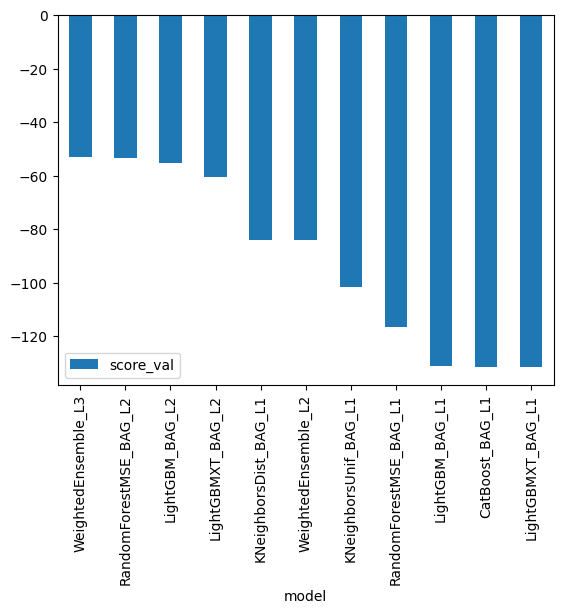

```python
predictor.leaderboard(silent=True).plot(kind='bar', x='model', y='score_val')
```

```python
# Get the best model parameter information
def get_model_parameter(predictor):
    model_info = predictor.info()
    best_model = predictor.get_model_best()
    time_fit = predictor.info()['time_fit_total']
    rows = predictor.info()['num_rows_train']
    features = predictor.info()['num_cols_train']
    stack = predictor.info()['best_model_stack_level']
    train_score = predictor.info()['best_model_score_val']
    print(f"Best Model: {best_model}")
    print(f"Time Fit Total: {time_fit}")
    print(f"Total Data Points: {rows}")
    print(f"Total Features: {features}")
    print(f"Stack Level: {stack}")
    print(f"Training Score: {train_score}")

    best_model_info = model_info['model_info'][best_model]
    hyperparameters = best_model_info.get('hyperparameters', {})
    print("Hyperparameters:")
    for param, value in hyperparameters.items():
        print(f"  {param}: {value}")

    ag_args_fit = best_model_info.get('ag_args_fit', {})
    print("AG Args Fit:")
    for arg, value in ag_args_fit.items():
        print(f"  {arg}: {value}")

get_model_parameter(predictor)
```

[output not shown]

### Create predictions from test dataset

```python
predictions = predictor.predict(test)
predictions.head()
```

```
0    23.437729
1    43.205894
2    46.618774
3    49.900612
4    52.341373
Name: count, dtype: float32
```

#### NOTE: Kaggle will reject the submission if we don't set everything to be > 0.

```python
# Describe the `predictions` series to see if there are any negative values
predictions.describe()
```

```
count    6493.000000
mean      100.578255
std        89.876862
min         3.276104
25%        19.912474
50%        63.806808
75%       168.780228
max       365.201843
Name: count, dtype: float64
```

```python
# How many negative values do we have?
0
```

```
0
```

```python
# Set them to zero
predictions = predictions.clip(lower=0)
predictions.describe()
```

```
count    6493.000000
mean      100.578255
std        89.876862
min         3.276104
25%        19.912474
50%        63.806808
75%       168.780228
max       365.201843
Name: count, dtype: float64
```

### Set predictions to submission dataframe, save, and submit

```python
submission["count"] = predictions
submission.to_csv("submission.csv", index=False)
```

```python
!kaggle competitions submit -c bike-sharing-demand -f submission.csv -m "first raw submission"
```

```
100% 188k/188k [00:00<00:00, 245kB/s]
Successfully submitted to Bike Sharing Demand
```

#### View submission via the command line or in the web browser under the competition's page - `My Submissions`

```python
!kaggle competitions submissions -c bike-sharing-demand | tail -n +1 | head -n 6
```

```
fileName                date                 description                 status    publicScore  privateScore
----------------------  -------------------  --------------------------  --------  -----------  ------------
submission.csv          2024-05-10 17:49:00  first raw submission        complete  1.80324      1.80324
submission_new_hpo.csv  2024-05-09 22:30:28  hyperparameters submission  complete  0.49941      0.49941
submission_new_hpo.csv  2024-05-09 22:25:09  hyperparameters submission  complete  1.79596      1.79596
submission_new_hpo.csv  2024-05-09 21:30:43  hyperparameters submission  complete  1.79596      1.79596
```

#### Initial score of `1.80324`

## Step 4: Exploratory Data Analysis and Creating an additional feature

- Any additional feature will do, but a great suggestion would be to separate out the datetime into hour, day, or month parts.

### Date Transformation and Anlaysis

```python
# Convert 'datetime' to datetime format if not already converted and extract useful time components
train['datetime'] = pd.to_datetime(train['datetime'])
train['year'] = train['datetime'].dt.year
train['month'] = train['datetime'].dt.month
train['hour'] = train['datetime'].dt.hour
train['dayofweek'] = train['datetime'].dt.dayofweek

# Checking the time span of the dataset
time_span = train['datetime'].agg(['min', 'max'])
time_span
```

```
min   2011-01-01 00:00:00
max   2012-12-19 23:00:00
Name: datetime, dtype: datetime64[ns]
```

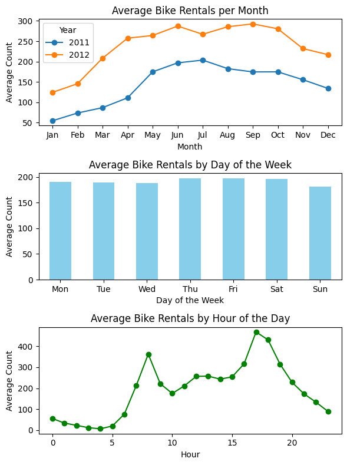

```python
# Group data by different time components to analyze seasonality and trends
grouped_by_month = train.groupby(['year', 'month'])['count'].mean().unstack(level=0)
grouped_by_dayofweek = train.groupby(['dayofweek'])['count'].mean()
grouped_by_hour = train.groupby(['hour'])['count'].mean()

# Plotting the grouped data
fig, axes = plt.subplots(nrows=3, ncols=1, figsize=(6, 8))

# Monthly trends for each year
grouped_by_month.plot(ax=axes[0], marker='o')
axes[0].set_title('Average Bike Rentals per Month')
axes[0].set_xlabel('Month')
axes[0].set_ylabel('Average Count')
axes[0].set_xticks(range(1, 13))
axes[0].set_xticklabels(['Jan', 'Feb', 'Mar', 'Apr', 'May', 'Jun', 'Jul', 'Aug', 'Sep', 'Oct', 'Nov', 'Dec'])
axes[0].legend(title='Year')

# Bike rentals by day of the week
grouped_by_dayofweek.plot(ax=axes[1], kind='bar', color='skyblue')
axes[1].set_title('Average Bike Rentals by Day of the Week')
axes[1].set_xlabel('Day of the Week')
axes[1].set_ylabel('Average Count')
axes[1].set_xticklabels(['Mon', 'Tue', 'Wed', 'Thu', 'Fri', 'Sat', 'Sun'], rotation=0)

# Bike rentals by hour of the day
grouped_by_hour.plot(ax=axes[2], color='green', marker='o')
axes[2].set_title('Average Bike Rentals by Hour of the Day')
axes[2].set_xlabel('Hour')
axes[2].set_ylabel('Average Count')

plt.tight_layout()
fig.savefig('date_analysis.png')

plt.show()
```

### Categorical Features Analysis

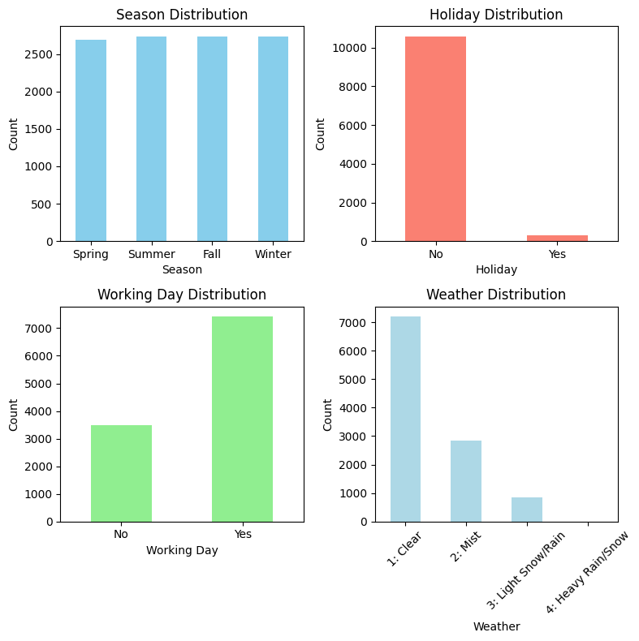

```python
# Creating plots to show the distribution of categorical features: season, holiday, workingday, and weather
fig, axes = plt.subplots(nrows=2, ncols=2, figsize=(8, 8))

# Plot for season distribution
train['season'].value_counts().sort_index().plot(kind='bar', ax=axes[0, 0], color='skyblue')
axes[0, 0].set_title('Season Distribution')
axes[0, 0].set_xlabel('Season')
axes[0, 0].set_ylabel('Count')
axes[0, 0].set_xticklabels(['Spring', 'Summer', 'Fall', 'Winter'], rotation=0)

# Plot for holiday distribution
train['holiday'].value_counts().sort_index().plot(kind='bar', ax=axes[0, 1], color='salmon')
axes[0, 1].set_title('Holiday Distribution')
axes[0, 1].set_xlabel('Holiday')
axes[0, 1].set_ylabel('Count')
axes[0, 1].set_xticklabels(['No', 'Yes'], rotation=0)

# Plot for workingday distribution
train['workingday'].value_counts().sort_index().plot(kind='bar', ax=axes[1, 0], color='lightgreen')
axes[1, 0].set_title('Working Day Distribution')
axes[1, 0].set_xlabel('Working Day')
axes[1, 0].set_ylabel('Count')
axes[1, 0].set_xticklabels(['No', 'Yes'], rotation=0)

# Plot for weather distribution
train['weather'].value_counts().sort_index().plot(kind='bar', ax=axes[1, 1], color='lightblue')
axes[1, 1].set_title('Weather Distribution')
axes[1, 1].set_xlabel('Weather')
axes[1, 1].set_ylabel('Count')
axes[1, 1].set_xticklabels(['1: Clear', '2: Mist', '3: Light Snow/Rain', '4: Heavy Rain/Snow'], rotation=45)

plt.tight_layout()
fig.savefig('categories_analysis.png')
plt.show()
```

### Analmoly Detection

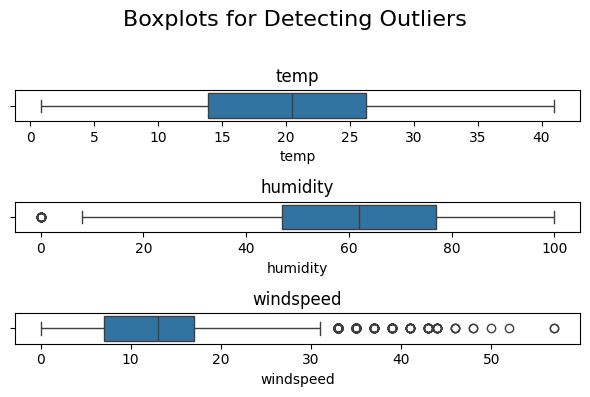

```python
# Generate boxplots for selected features to visually inspect for outliers
features_to_plot = ['temp', 'humidity', 'windspeed']
fig, axes = plt.subplots(nrows=3, ncols=1, figsize=(6, 4))
fig.suptitle('Boxplots for Detecting Outliers', fontsize=16)

for i, feature in enumerate(features_to_plot):
    ax = axes[i]
    sns.boxplot(x=train[feature], ax=ax)
    ax.set_title(feature)

plt.tight_layout(rect=[0, 0, 1, 0.96])  # Adjust the layout to make room for the title
fig.savefig('outlier_detection.png')
plt.show()
```

```python
# Define outliers for windspeed using the IQR method
Q1 = train['windspeed'].quantile(0.25)
Q3 = train['windspeed'].quantile(0.75)
IQR = Q3 - Q1
outlier_threshold_high = Q3 + 1.5 * IQR

# Filter data where windspeed is considered an outlier
windspeed_outliers = train[train['windspeed'] > outlier_threshold_high]

# Display the subset of data considered as outliers for windspeed
windspeed_outliers.head(), windspeed_outliers.shape
```

```
(               datetime  season  holiday  workingday  weather  temp  atemp  \
 175 2011-01-08 14:00:00       1        0           0        1  8.20  8.335
 178 2011-01-08 17:00:00       1        0           0        1  6.56  6.060
 194 2011-01-09 09:00:00       1        0           0        1  4.92  3.790
 196 2011-01-09 11:00:00       1        0           0        1  6.56  6.060
 265 2011-01-12 12:00:00       1        0           1        1  8.20  7.575

      humidity  windspeed  casual  registered  count  year  month  hour  \
 175        32    32.9975      12          83     95  2011      1    14
 178        37    36.9974       5          64     69  2011      1    17
 194        46    35.0008       0          19     19  2011      1     9
 196        40    35.0008       2          47     49  2011      1    11
 265        47    39.0007       3          52     55  2011      1    12

      dayofweek
 175          5
 178          5
 194          6
 196          6
 265          2  ,
 (227, 16))
```

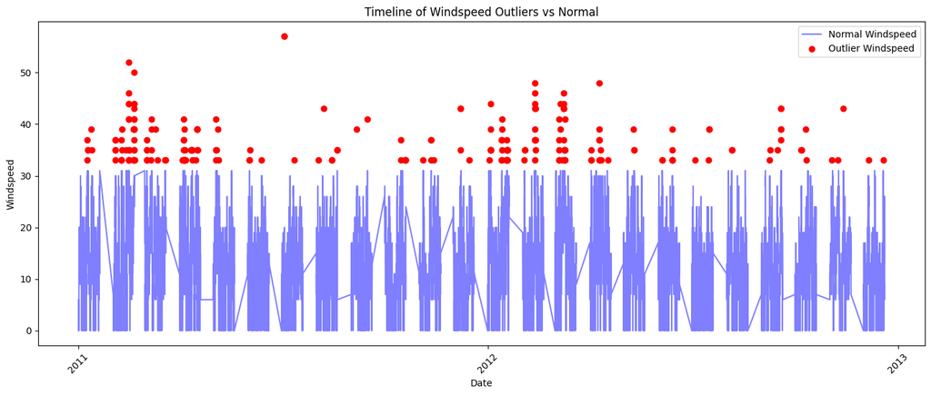

```
(0.11403451230475668, -0.0636334796446429)
```

```python
# Prepare data for timeline plot
windspeed_outliers.loc[:, 'datetime'] = pd.to_datetime(windspeed_outliers['datetime'])
normal_windspeed = train[train['windspeed'] <= outlier_threshold_high]
normal_windspeed.loc[:, 'datetime'] = pd.to_datetime(normal_windspeed['datetime'])

# Plot timeline of windspeeds highlighting outliers
fig, ax = plt.subplots(figsize=(14, 6))
ax.plot(normal_windspeed['datetime'], normal_windspeed['windspeed'], label='Normal Windspeed', color='blue', alpha=0.5)
ax.scatter(windspeed_outliers['datetime'], windspeed_outliers['windspeed'], color='red', label='Outlier Windspeed')
ax.set_title('Timeline of Windspeed Outliers vs Normal')
ax.set_ylabel('Windspeed')
ax.set_xlabel('Date')
ax.legend()
ax.xaxis.set_major_locator(mdates.YearLocator())
ax.xaxis.set_major_formatter(mdates.DateFormatter('%Y'))
plt.xticks(rotation=45)
plt.tight_layout()
fig.savefig('windspeed_outlier_analysis.png')
plt.show()

# Correlation analysis
correlation_normal = normal_windspeed[['windspeed', 'count']].corr().iloc[0, 1]
correlation_outliers = windspeed_outliers[['windspeed', 'count']].corr().iloc[0, 1]

correlation_normal, correlation_outliers
```

**Windspeed Timeline Visualization**

The timeline chart above plots the normal windspeeds (in blue) and highlights the outliers (in red). This visual helps illustrate the distribution of these outliers over time, indicating that they aren't isolated to specific periods but rather scattered across different dates.

```python
# Define outliers for humidity using the IQR method
Q1_humidity = train['humidity'].quantile(0.25)
Q3_humidity = train['humidity'].quantile(0.75)
IQR_humidity = Q3_humidity - Q1_humidity
outlier_low_humidity = Q1_humidity - 1.5 * IQR_humidity

# Filter data to remove outliers in windspeed and humidity
cleaned_data = train[(train['windspeed'] <= outlier_threshold_high) & (train['humidity'] > outlier_low_humidity)]

# Description of how many data points were removed
original_data_count = train.shape[0]
cleaned_data_count = cleaned_data.shape[0]
removed_data_count = original_data_count - cleaned_data_count

print(f"Outliers: {removed_data_count}, Original length: {original_data_count}, Clean length: {cleaned_data_count}")
```

```
Outliers: 248, Original length: 10886, Clean length: 10638
```

### Correlation Analysis

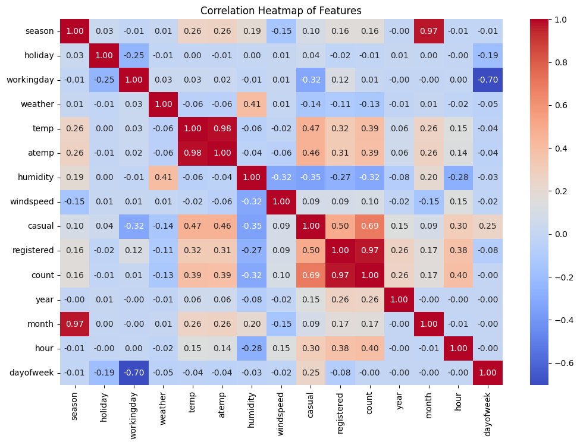

```python
# Calculate the correlation matrix
correlation_matrix = train.corr(numeric_only=True)

# Generate a heatmap of the correlations
plt.figure(figsize=(12, 8))
heatmap = sns.heatmap(correlation_matrix, annot=True, fmt=".2f", cmap='coolwarm')
plt.title('Correlation Heatmap of Features')
fig.savefig('correlation_analysis.png')
plt.show()
```

### One-hot coding for categorical features

```python
# Final features cleaning
cleaned_data = cleaned_data.drop(columns = ['atemp', 'casual', 'registered'])
dummy_data = pd.get_dummies(cleaned_data, columns=['season', 'weather' ,'year', 'month', 'hour'], drop_first=True)
dummy_data = dummy_data.drop(columns = ['datetime'])
dummy_data.head(2)
```

|  | holiday | workingday | temp | humidity | windspeed | count | dayofweek | season_2 | season_3 | season_4 | ... | hour_14 | hour_15 | hour_16 | hour_17 | hour_18 | hour_19 | hour_20 | hour_21 | hour_22 | hour_23 |
| --- | --- | --- | --- | --- | --- | --- | --- | --- | --- | --- | --- | --- | --- | --- | --- | --- | --- | --- | --- | --- | --- |
| 0 | 0 | 0 | 9.84 | 81 | 0.0 | 16 | 5 | False | False | False | ... | False | False | False | False | False | False | False | False | False | False |
| 1 | 0 | 0 | 9.02 | 80 | 0.0 | 40 | 5 | False | False | False | ... | False | False | False | False | False | False | False | False | False | False |

2 rows × 48 columns

## Step 5: Rerun the model with the same settings as before, just with more features

```python
label = 'count'
predictor_new_features = TabularPredictor(
    label=label,
    eval_metric='root_mean_squared_error'
).fit(
    train_data = dummy_data,
    presets='best_quality',
    time_limit=600
)
```

```
No path specified. Models will be saved in: "AutogluonModels/ag-20240510_175013"
Presets specified: ['best_quality']
Setting dynamic_stacking from 'auto' to True. Reason: Enable dynamic_stacking when use_bag_holdout is disabled. (use_bag_holdout=False)
Stack configuration (auto_stack=True): num_stack_levels=1, num_bag_folds=8, num_bag_sets=1
Dynamic stacking is enabled (dynamic_stacking=True). AutoGluon will try to determine whether the input data is affected by stacked overfitting and enable or disable stacking as a consequence.
Detecting stacked overfitting by sub-fitting AutoGluon on the input data. That is, copies of AutoGluon will be sub-fit on subset(s) of the data. Then, the holdout validation data is used to detect stacked overfitting.
Sub-fit(s) time limit is: 600 seconds.
Starting holdout-based sub-fit for dynamic stacking. Context path is: AutogluonModels/ag-20240510_175013/ds_sub_fit/sub_fit_ho.
Running the sub-fit in a ray process to avoid memory leakage.
Spend 192 seconds for the sub-fit(s) during dynamic stacking.
Time left for full fit of AutoGluon: 408 seconds.
Starting full fit now with num_stack_levels 1.
Beginning AutoGluon training ... Time limit = 408s
AutoGluon will save models to "AutogluonModels/ag-20240510_175013"
=================== System Info ===================
AutoGluon Version:  1.1.0
Python Version:     3.10.12
Operating System:   Linux
Platform Machine:   x86_64
Platform Version:   #1 SMP PREEMPT_DYNAMIC Sat Nov 18 15:31:17 UTC 2023
CPU Count:          2
Memory Avail:       9.50 GB / 12.67 GB (74.9%)
Disk Space Avail:   74.33 GB / 107.72 GB (69.0%)
===================================================
Train Data Rows:    10638
Train Data Columns: 47
Label Column:       count
Problem Type:       regression
Preprocessing data ...
Using Feature Generators to preprocess the data ...
Fitting AutoMLPipelineFeatureGenerator...
	Available Memory:                    9724.17 MB
	Train Data (Original)  Memory Usage: 0.86 MB (0.0% of available memory)
	Inferring data type of each feature based on column values. Set feature_metadata_in to manually specify special dtypes of the features.
	Stage 1 Generators:
		Fitting AsTypeFeatureGenerator...
			Note: Converting 43 features to boolean dtype as they only contain 2 unique values.
	Stage 2 Generators:
		Fitting FillNaFeatureGenerator...
	Stage 3 Generators:
```

[output cut: 73 more lines]

```
	Fitting 8 child models (S1F1 - S1F8) | Fitting with ParallelLocalFoldFittingStrategy (2 workers, per: cpus=1, gpus=0, memory=0.17%)
	-38.8467	 = Validation score   (-root_mean_squared_error)
	36.32s	 = Training   runtime
	0.16s	 = Validation runtime
Fitting model: RandomForestMSE_BAG_L2 ... Training model for up to 48.53s of the 48.46s of remaining time.
	-39.6457	 = Validation score   (-root_mean_squared_error)
	59.83s	 = Training   runtime
	1.05s	 = Validation runtime
Fitting model: WeightedEnsemble_L3 ... Training model for up to 360.0s of the -14.57s of remaining time.
	Ensemble Weights: {'LightGBM_BAG_L2': 0.458, 'LightGBMXT_BAG_L1': 0.208, 'LightGBMXT_BAG_L2': 0.167, 'RandomForestMSE_BAG_L2': 0.083, 'LightGBM_BAG_L1': 0.042, 'CatBoost_BAG_L1': 0.042}
	-38.5267	 = Validation score   (-root_mean_squared_error)
	0.05s	 = Training   runtime
	0.0s	 = Validation runtime
AutoGluon training complete, total runtime = 423.11s ... Best model: "WeightedEnsemble_L3"
TabularPredictor saved. To load, use: predictor = TabularPredictor.load("AutogluonModels/ag-20240510_175013")
```

```python
predictor_new_features.fit_summary()
```

```
*** Summary of fit() ***
Estimated performance of each model:
                     model   score_val              eval_metric  pred_time_val    fit_time  pred_time_val_marginal  fit_time_marginal  stack_level  can_infer  fit_order
0      WeightedEnsemble_L3  -38.526714  root_mean_squared_error      17.313334  384.003859                0.001261           0.051213            3       True         11
1          LightGBM_BAG_L2  -38.846719  root_mean_squared_error      15.971131  289.312842                0.157358          36.316766            2       True          9
2      WeightedEnsemble_L2  -39.115851  root_mean_squared_error      14.143250  221.880445                0.001192           0.041658            2       True          7
3        LightGBMXT_BAG_L2  -39.586330  root_mean_squared_error      16.103526  287.810564                0.289753          34.814488            2       True          8
4   RandomForestMSE_BAG_L2  -39.645710  root_mean_squared_error      16.864962  312.821391                1.051189          59.825315            2       True         10
5        LightGBMXT_BAG_L1  -39.897256  root_mean_squared_error       9.374611   74.202605                9.374611          74.202605            1       True          3
6          LightGBM_BAG_L1  -41.202923  root_mean_squared_error       4.637515   58.695683                4.637515          58.695683            1       True          4
7          CatBoost_BAG_L1  -42.674992  root_mean_squared_error       0.129931   88.940498                0.129931          88.940498            1       True          6
8   RandomForestMSE_BAG_L1  -51.336054  root_mean_squared_error       1.535568   31.106517                1.535568          31.106517            1       True          5
9    KNeighborsUnif_BAG_L1 -161.897766  root_mean_squared_error       0.067072    0.023080                0.067072           0.023080            1       True          1
10   KNeighborsDist_BAG_L1 -170.937741  root_mean_squared_error       0.069075    0.027694                0.069075           0.027694            1       True          2
Number of models trained: 11
Types of models trained:
{'StackerEnsembleModel_RF', 'StackerEnsembleModel_KNN', 'StackerEnsembleModel_CatBoost', 'WeightedEnsembleModel', 'StackerEnsembleModel_LGB'}
Bagging used: True  (with 8 folds)
Multi-layer stack-ensembling used: True  (with 3 levels)
Feature Metadata (Processed):
(raw dtype, special dtypes):
('float', [])     :  2 | ['temp', 'windspeed']
('int', [])       :  2 | ['humidity', 'dayofweek']
('int', ['bool']) : 43 | ['holiday', 'workingday', 'season_2', 'season_3', 'season_4', ...]
*** End of fit() summary ***
```

```
{'model_types': {'KNeighborsUnif_BAG_L1': 'StackerEnsembleModel_KNN',
  'KNeighborsDist_BAG_L1': 'StackerEnsembleModel_KNN',
  'LightGBMXT_BAG_L1': 'StackerEnsembleModel_LGB',
  'LightGBM_BAG_L1': 'StackerEnsembleModel_LGB',
  'RandomForestMSE_BAG_L1': 'StackerEnsembleModel_RF',
  'CatBoost_BAG_L1': 'StackerEnsembleModel_CatBoost',
  'WeightedEnsemble_L2': 'WeightedEnsembleModel',
  'LightGBMXT_BAG_L2': 'StackerEnsembleModel_LGB',
  'LightGBM_BAG_L2': 'StackerEnsembleModel_LGB',
  'RandomForestMSE_BAG_L2': 'StackerEnsembleModel_RF',
  'WeightedEnsemble_L3': 'WeightedEnsembleModel'},
 'model_performance': {'KNeighborsUnif_BAG_L1': -161.89776647288562,
  'KNeighborsDist_BAG_L1': -170.93774072837655,
  'LightGBMXT_BAG_L1': -39.897255605081085,
  'LightGBM_BAG_L1': -41.20292284160487,
  'RandomForestMSE_BAG_L1': -51.33605376652099,
  'CatBoost_BAG_L1': -42.67499209959858,
  'WeightedEnsemble_L2': -39.1158511158497,
  'LightGBMXT_BAG_L2': -39.5863296070799,
  'LightGBM_BAG_L2': -38.846719371846675,
  'RandomForestMSE_BAG_L2': -39.64570971657126,
  'WeightedEnsemble_L3': -38.52671360800118},
 'model_best': 'WeightedEnsemble_L3',
 'model_paths': {'KNeighborsUnif_BAG_L1': ['KNeighborsUnif_BAG_L1'],
  'KNeighborsDist_BAG_L1': ['KNeighborsDist_BAG_L1'],
  'LightGBMXT_BAG_L1': ['LightGBMXT_BAG_L1'],
  'LightGBM_BAG_L1': ['LightGBM_BAG_L1'],
  'RandomForestMSE_BAG_L1': ['RandomForestMSE_BAG_L1'],
  'CatBoost_BAG_L1': ['CatBoost_BAG_L1'],
  'WeightedEnsemble_L2': ['WeightedEnsemble_L2'],
  'LightGBMXT_BAG_L2': ['LightGBMXT_BAG_L2'],
  'LightGBM_BAG_L2': ['LightGBM_BAG_L2'],
  'RandomForestMSE_BAG_L2': ['RandomForestMSE_BAG_L2'],
  'WeightedEnsemble_L3': ['WeightedEnsemble_L3']},
 'model_fit_times': {'KNeighborsUnif_BAG_L1': 0.023079633712768555,
  'KNeighborsDist_BAG_L1': 0.027693748474121094,
  'LightGBMXT_BAG_L1': 74.20260453224182,
  'LightGBM_BAG_L1': 58.69568347930908,
  'RandomForestMSE_BAG_L1': 31.10651659965515,
  'CatBoost_BAG_L1': 88.9404981136322,
```

[output cut: 89 more lines]

```
 9        0.067072    0.023080                0.067072           0.023080
 10       0.069075    0.027694                0.069075           0.027694

     stack_level  can_infer  fit_order
 0             3       True         11
 1             2       True          9
 2             2       True          7
 3             2       True          8
 4             2       True         10
 5             1       True          3
 6             1       True          4
 7             1       True          6
 8             1       True          5
 9             1       True          1
 10            1       True          2  }
```

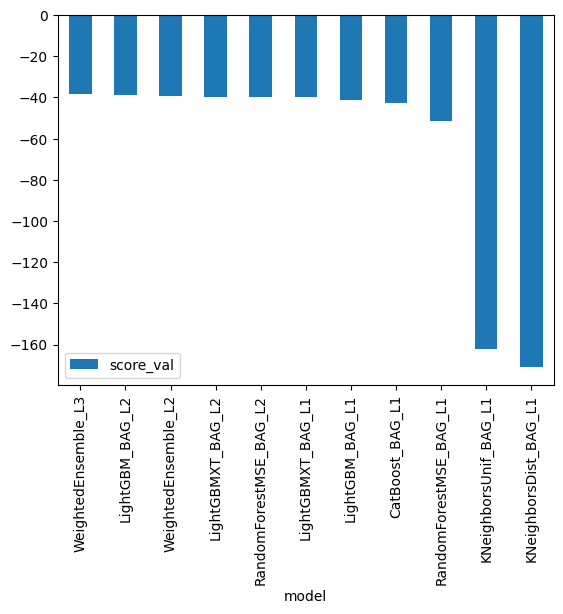

```python
predictor_new_features.leaderboard(silent=True).plot(kind='bar', x='model', y='score_val')
```

```python
# get_model_parameter(predictor_new_features)
```

```python
# Make prediction on test set
test['datetime'] = pd.to_datetime(test['datetime'])
test['year'] = test['datetime'].dt.year
test['month'] = test['datetime'].dt.month
test['hour'] = test['datetime'].dt.hour
test['dayofweek'] = test['datetime'].dt.dayofweek
test_dummy = pd.get_dummies(test, columns=['season', 'weather' ,'year', 'month', 'hour'], drop_first=True)
test_dummy.head(2)
```

|  | datetime | holiday | workingday | temp | atemp | humidity | windspeed | dayofweek | season_2 | season_3 | ... | hour_14 | hour_15 | hour_16 | hour_17 | hour_18 | hour_19 | hour_20 | hour_21 | hour_22 | hour_23 |
| --- | --- | --- | --- | --- | --- | --- | --- | --- | --- | --- | --- | --- | --- | --- | --- | --- | --- | --- | --- | --- | --- |
| 0 | 2011-01-20 00:00:00 | 0 | 1 | 10.66 | 11.365 | 56 | 26.0027 | 3 | False | False | ... | False | False | False | False | False | False | False | False | False | False |
| 1 | 2011-01-20 01:00:00 | 0 | 1 | 10.66 | 13.635 | 56 | 0.0000 | 3 | False | False | ... | False | False | False | False | False | False | False | False | False | False |

2 rows × 49 columns

```python
predictions_new_features = predictor_new_features.predict(test_dummy.drop(columns=['atemp', 'datetime']))
predictions_new_features.describe()
```

```
count    6493.000000
mean      187.172729
std       174.451859
min        -9.743912
25%        46.688721
50%       141.434433
75%       275.547394
max       902.448120
Name: count, dtype: float64
```

```python
# Remember to set all negative values to zero
predictions_new_features = predictions_new_features.clip(lower=0)
predictions_new_features.describe()
```

```
count    6493.000000
mean      187.182541
std       174.441162
min         0.000000
25%        46.688721
50%       141.434433
75%       275.547394
max       902.448120
Name: count, dtype: float64
```

```python
# Same submitting predictions
submission["count"] = predictions_new_features
submission.to_csv("submission_new_features.csv", index=False)
```

```python
!kaggle competitions submit -c bike-sharing-demand -f submission_new_features.csv -m "first new features submission"
```

```
100% 188k/188k [00:00<00:00, 239kB/s]
Successfully submitted to Bike Sharing Demand
```

```python
!kaggle competitions submissions -c bike-sharing-demand | tail -n +1 | head -n 6
```

```
fileName                     date                 description                    status    publicScore  privateScore
---------------------------  -------------------  -----------------------------  --------  -----------  ------------
submission_new_features.csv  2024-05-10 18:04:10  first new features submission  complete  0.47566      0.47566
submission.csv               2024-05-10 17:49:00  first raw submission           complete  1.80324      1.80324
submission_new_hpo.csv       2024-05-09 22:30:28  hyperparameters submission     complete  0.49941      0.49941
submission_new_hpo.csv       2024-05-09 22:25:09  hyperparameters submission     complete  1.79596      1.79596
```